# Mini Project 2

25 de abril de 2017

## Abstract

We used a dataset of movies reviews, with 5331 positive reviews and 2332 negative reviews, we get the dataset from a project of github where is use to practice data science with python.

We used this dataset to predict if a new review is negative or positive with naive bayes.

## Index

###### 1: The dataset.

###### 2: Plot of reviews.

###### 3: Preprocessing.

###### 4: The wordcloud of the clean dataset.

###### 5: Barplot of most common words.

###### 6: Visualizing text data.

###### 7: List of most common words.

###### 8: Naive Bayes.

###### 9: Comparative table with laplace.

###### 10: Conclusions, Limitations and Advantages.

## The dataset

```r
summary(dsMovies)
```

```
##      type             message
##  Length:7663        Length:7663
##  Class :character   Class :character
##  Mode  :character   Mode  :character
```

```r
str(dsMovies)
```

```
## 'data.frame':    7663 obs. of  2 variables:
##  $ type   : chr  "negative" "negative" "negative" "negative" ...
##  $ message: chr  "it's a mindless action flick with a twist -- far better suited to video-viewing than the multiplex . " "after a while , the only way for a reasonably intelligent person to get through the country bears is to ponder how a whole segm"| __truncated__ "we get light showers of emotio…
```

## The dataset (2)

```r
head(dsMovies)
```

```
##       type
## 1 negative
## 2 negative
## 3 negative
## 4 negative
## 5 negative
## 6 negative
##                                                                                                                                                                                                     message
## 1                                                                                                     it's a mindless action flick with a twist -- far better suited to video-viewing than the multiplex .
## 2 after a while , the only way for a reasonably intelligent person to get through the country bears is to ponder how a whole segment of pop-music history has been allowed to get wet , fuzzy and sticky .
## 3                                                         we get light showers of emotion a couple of times , but then -- strangely -- these wane to an inconsistent and ultimately unsatisfying drizzle .
## 4                                                                                                                                               summer's far too fleeting to squander on offal like this .
## 5                                                                                                             the film is grossly contradictory in conveying its social message , if indeed there is one .
## 6                                                            often lingers just as long on the irrelevant as on the engaging , which gradually turns what time is it there ? into how long is this movie ?
```

## The dataset (3)

```r
tail(dsMovies)
```

```
##          type
## 7658 positive
## 7659 positive
## 7660 positive
## 7661 positive
## 7662 positive
## 7663 positive
##                                                                                                                                               message
## 7658                                               [has] an immediacy and an intimacy that sucks you in and dares you not to believe it's all true .
## 7659                                          it treats ana's journey with honesty that is tragically rare in the depiction of young women in film .
## 7660 captivates as it shows excess in business and pleasure , allowing us to find the small , human moments , and leaving off with a grand whimper .
## 7661                                                                                a refreshingly realistic , affectation-free coming-of-age tale .
## 7662                              how good this film might be , depends if you believe that the shocking conclusion is too much of a plunge or not .
## 7663          great fun both for sports aficionados and for ordinary louts whose idea of exercise is climbing the steps of a stadium-seat megaplex .
```

## The dataset (4)

```r
dsMovies$type <- factor(dsMovies$type)
table(dsMovies$type)
```

```
##
## negative positive
##     2332     5331
```

## Plot of reviews

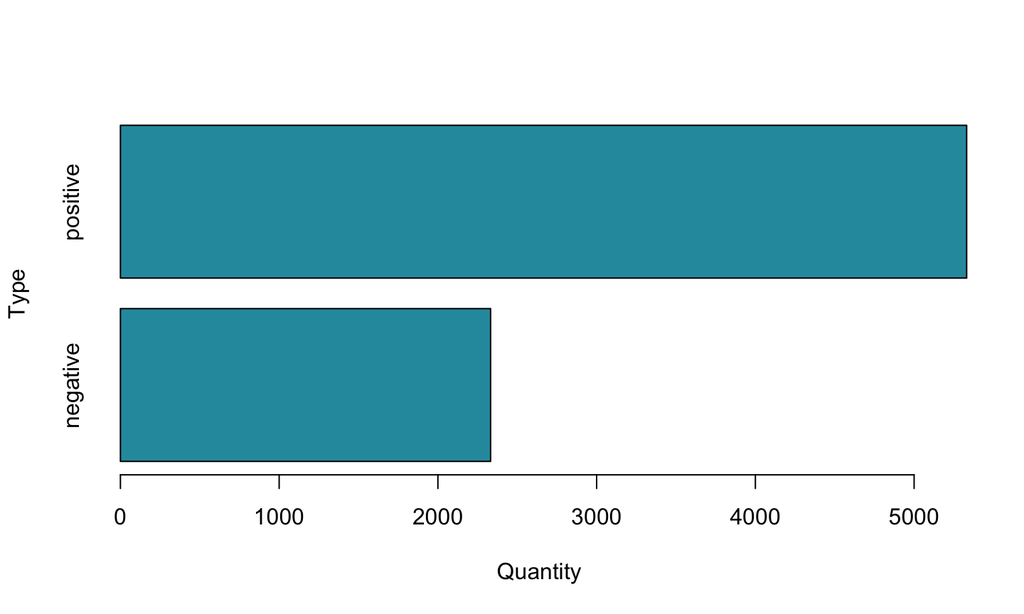

```r
barplot(table(dsMovies$type), xlab = "Quantity", ylab = "Type", horiz = TRUE, col='#2999AD')
```

## Preprocessing

```r
library("tm")
dsMoviesCorpus <- VCorpus(VectorSource (dsMovies$message))
inspect(dsMoviesCorpus[1:2])
```

```
## <<VCorpus>>
## Metadata:  corpus specific: 0, document level (indexed): 0
## Content:  documents: 2
##
## [[1]]
## <<PlainTextDocument>>
## Metadata:  7
## Content:  chars: 101
##
## [[2]]
## <<PlainTextDocument>>
## Metadata:  7
## Content:  chars: 201
```

## Preprocessing (2)

```r
library("tm")
print(dsMoviesCorpus[[1]])
```

```
## <<PlainTextDocument>>
## Metadata:  7
## Content:  chars: 101
```

```r
as.character(dsMoviesCorpus[[1]])
```

```
## [1] "it's a mindless action flick with a twist -- far better suited to video-viewing than the multiplex . "
```

## Preprocessing (3) To Lowercase

```r
dsMovies_clean <- tm_map ( dsMoviesCorpus, content_transformer(tolower))
as.character(dsMoviesCorpus[[1]])
```

```
## [1] "it's a mindless action flick with a twist -- far better suited to video-viewing than the multiplex . "
```

```r
as.character(dsMovies_clean[[1]])
```

```
## [1] "it's a mindless action flick with a twist -- far better suited to video-viewing than the multiplex . "
```

## Preprocessing (4) Remove Numbers

```r
dsMovies_clean <- tm_map ( dsMovies_clean, removeNumbers)
as.character(dsMoviesCorpus[[32]])
```

```
## [1] "one of the worst films of 2002 . "
```

```r
as.character(dsMovies_clean[[32]])
```

```
## [1] "one of the worst films of  . "
```

## Preprocessing (5) Remove STOP WORDS

```r
dsMovies_clean <- tm_map ( dsMovies_clean, removeWords, stopwords('spanish'))
dsMovies_clean <- tm_map ( dsMovies_clean, removeWords, stopwords())
as.character(dsMoviesCorpus[[6]])
```

```
## [1] "often lingers just as long on the irrelevant as on the engaging , which gradually turns what time is it there ? into how long is this movie ? "
```

```r
as.character(dsMovies_clean[[6]])
```

```
## [1] "often lingers just  long   irrelevant    engaging ,  gradually turns  time    ?   long   movie ? "
```

## Preprocessing (6) Remove Punctuation

```r
dsMovies_clean <- tm_map ( dsMovies_clean, removePunctuation)
as.character(dsMoviesCorpus[[6]])
```

```
## [1] "often lingers just as long on the irrelevant as on the engaging , which gradually turns what time is it there ? into how long is this movie ? "
```

```r
as.character(dsMovies_clean[[6]])
```

```
## [1] "often lingers just  long   irrelevant    engaging   gradually turns  time       long   movie  "
```

## Preprocessing (7) Remove Spaces

```r
dsMovies_clean <- tm_map ( dsMovies_clean, stripWhitespace)
as.character(dsMoviesCorpus[[1576]])
```

```
## [1] "hollywood's answer to an air ball . "
```

```r
as.character(dsMovies_clean[[1576]])
```

```
## [1] "hollywoods answer air ball "
```

## Preprocessing (8) Create the DTM

```r
dsMovies_dtm <- DocumentTermMatrix (dsMovies_clean)
str(dsMovies_dtm)
```

```
## List of 6
##  $ i       : int [1:78753] 1 1 1 1 1 1 1 1 1 2 ...
##  $ j       : int [1:78753] 136 1327 5259 5569 9238 9551 14253 15273 15831 402 ...
##  $ v       : num [1:78753] 1 1 1 1 1 1 1 1 1 1 ...
##  $ nrow    : int 7663
##  $ ncol    : int 16567
##  $ dimnames:List of 2
##   ..$ Docs : chr [1:7663] "1" "2" "3" "4" ...
##   ..$ Terms: chr [1:16567] "<c2><bd>" "<c3><a9>lan" "<e2><80><93>" "<e2><80><94>" ...
##  - attr(*, "class")= chr [1:2] "DocumentTermMatrix" "simple_triplet_matrix"
##  - attr(*, "weighting")= chr [1:2] "term frequency" "tf"
```

## Preprocessing (9) Create the train and test set

```r
dsMovies_dtm_train <- dsMovies_dtm[1:5364, ]
dsMovies_dtm_test <- dsMovies_dtm[5365:7663, ]
dsMovies_train_labels <- dsMovies[1:5364,]$type
dsMovies_test_labels <- dsMovies[5365:7663,]$type
prop.table(table(dsMovies_train_labels))
```

```
## dsMovies_train_labels
##  negative  positive
## 0.3296048 0.6703952
```

```r
prop.table(table(dsMovies_test_labels))
```

```
## dsMovies_test_labels
##  negative  positive
## 0.2453241 0.7546759
```

## The wordcloud of the clean dataset

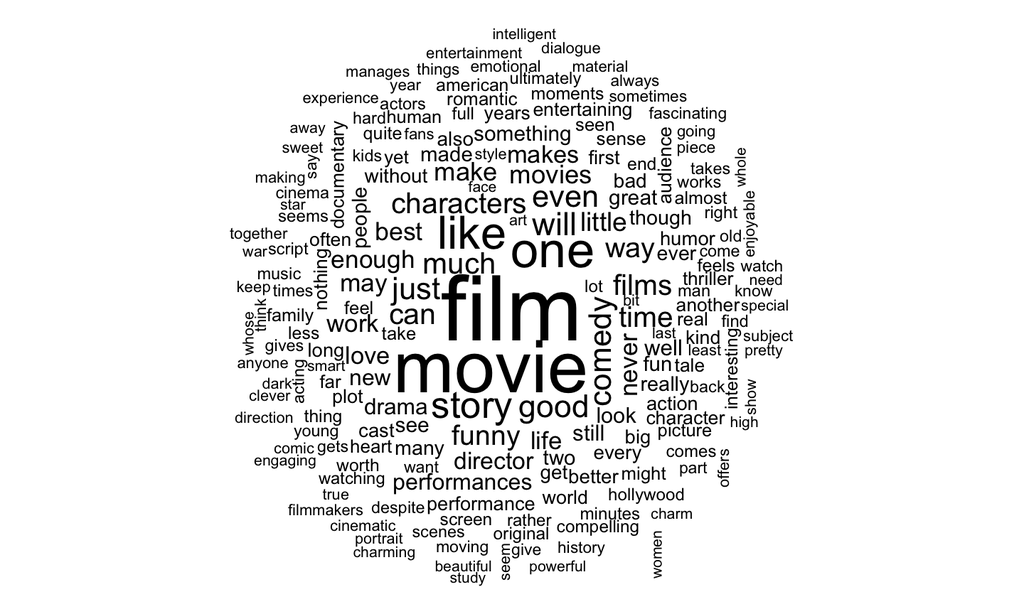

```r
wordcloud(dsMovies_clean, min.freq = 50, random.order = FALSE)
```

## Barplot of most common words

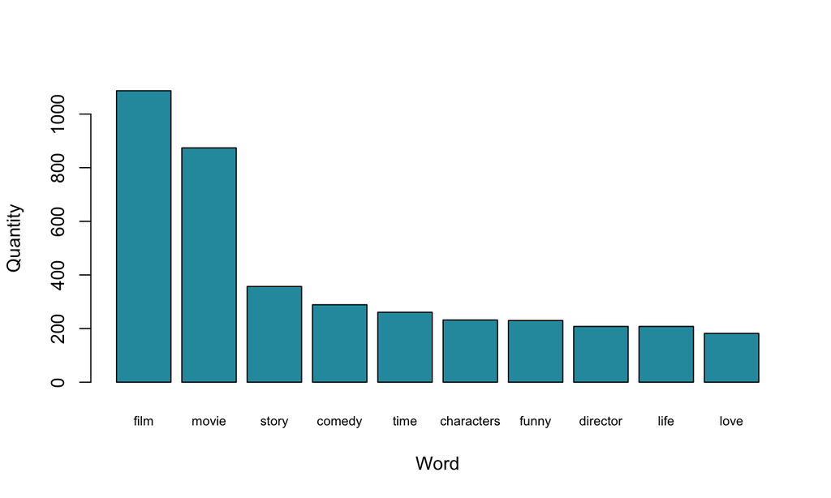

```r
barplot(res[1:10,]$n, xlab = "Word", ylab = "Quantity", horiz = FALSE, col='#2999AD',names.arg=res[1:10,]$word, cex.names=0.7)
```

## Visualizing text data (ggplot2)

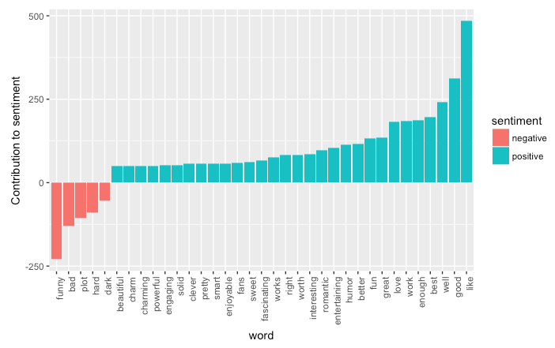

## List of most common words

```r
res[1:10,]
```

```
## # A tibble: 10 x 2
##          word     n
##         <chr> <int>
## 1        film  1087
## 2       movie   874
## 3       story   357
## 4      comedy   289
## 5        time   261
## 6  characters   232
## 7       funny   230
## 8    director   208
## 9        life   208
## 10       love   182
```

## Naive Bayes. Formula

\(P(A|B)=\frac{P(B|A)P(A)}{P(B)}\)

## Naive Bayes. Frequent Words

```r
dsMovies_freq_words <- findFreqTerms(dsMovies_dtm_train,20)
str(dsMovies_freq_words)
```

```
##  chr [1:429] "acted" "acting" "action" "actor" "actors" ...
```

```r
dsMovies_dtm_freq_train <- dsMovies_dtm_train[,dsMovies_freq_words]
dsMovies_dtm_freq_test <- dsMovies_dtm_test[,dsMovies_freq_words]
```

## Naive Bayes. Frequent Words (2)

```r
dsMovies_dtm_freq_train
```

```
## <<DocumentTermMatrix (documents: 5364, terms: 429)>>
## Non-/sparse entries: 21067/2280089
## Sparsity           : 99%
## Maximal term length: 14
## Weighting          : term frequency (tf)
```

```r
dsMovies_dtm_freq_test
```

```
## <<DocumentTermMatrix (documents: 2299, terms: 429)>>
## Non-/sparse entries: 8863/977408
## Sparsity           : 99%
## Maximal term length: 14
## Weighting          : term frequency (tf)
```

## Naive Bayes. (2) Convert to categorical data.

```r
converts_counts <- function(x){x <- ifelse(x>0,"Yes","No")}
dsMovies_train <- apply(dsMovies_dtm_freq_train, MARGIN = 2, converts_counts)
dsMovies_test <- apply(dsMovies_dtm_freq_test, MARGIN = 2, converts_counts)
```

## Naive Bayes. (3) Clasification outputs without laplace.

```r
library(e1071)
dsMovies_classifier <- naiveBayes(dsMovies_train,dsMovies_train_labels)
dsMovies_text_pred <- predict(dsMovies_classifier,dsMovies_test)
table(dsMovies_text_pred)
```

```
## dsMovies_text_pred
## negative positive
##      473     1826
```

## Naive Bayes. (4) Frequency table without laplace.

```r
table(dsMovies_text_pred,dsMovies_test_labels)
```

```
##                   dsMovies_test_labels
## dsMovies_text_pred negative positive
##           negative      230      243
##           positive      334     1492
```

## Naive Bayes. (5) Frequency table with laplace.

\(P(X_i = x_i | Y = y) = 0\)

```r
library(e1071)
dsMovies_classifier <- naiveBayes(dsMovies_train,dsMovies_train_labels,laplace = 1)
dsMovies_text_pred <- predict(dsMovies_classifier,dsMovies_test)
table(dsMovies_text_pred,dsMovies_test_labels)
```

```
##                   dsMovies_test_labels
## dsMovies_text_pred negative positive
##           negative      222      237
##           positive      342     1498
```

[figure not shown]

[figure not shown]